# Part 2 - RNA-seq analysis with DESeq2

2024-03-06

## Introduction

The following script is based on the [DESeq2 worflow](https://bioconductor.org/packages/release/bioc/vignettes/DESeq2/inst/doc/DESeq2.html), and consists on the analysis of RNA-seq data from the count matrix input.

### Overview of RNA-seq

RNA sequencing (RNA-seq) measures the abundance of the transcription of each gene, quantifying gene expression.

Steps:

1. RNA isolation
2. Fragmentation (few hundred bases long)
3. Library preparation (reverse-transcription and amplification)
4. Sequencing (output reads)
5. Alignment to reference genome (e.g., HISAT2)
6. Quantification of reads per gene (e.g., featureCounts)

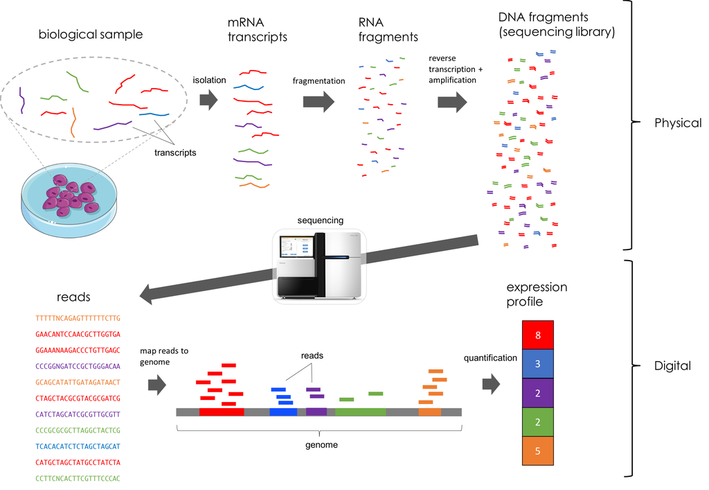

image from (https://mbernste.github.io/posts/rna_seq_basics/)

### Upload count matrix and coldata

DESeq2 requires the upload of raw count reads (integer values).

```r
setwd("C:/Users/ricar/Documents/Workshop_2024/")

coldata <- read.table("data/coldata_RNAseq.txt")
head(coldata)
```

```
##    Sample Group Age Sex
## A1     A1     A  20   M
## A2     A2     A  55   M
## A3     A3     A  34   F
## B1     B1     B  25   F
## B2     B2     B  16   F
## B3     B3     B  67   F
```

```r
cts <- read.table("data/cts.txt")
head(cts)
```

```
##                A1   A2    A3   B1   B2   B3
## WASH7P       2070 2077  3135 1001 1125 1718
## MIR1302-10      0    0     0    0    0    0
## FAM138A         0    0     0    1    0    0
## OR4F5           0    0     0    0    0    0
## LOC729737    4943 8977 14665  578 1048  170
## LOC100132287  282  229   280   10   20    8
```

```r
all(colnames(cts)==coldata$Sample)
```

```
## [1] TRUE
```

### Construct the DESeqDataSet

```r
library(DESeq2) #after installation

dds <- DESeqDataSetFromMatrix(countData = cts,
                              colData = coldata,
                              design = ~ Group)
dds
```

```
## class: DESeqDataSet
## dim: 23729 6
## metadata(1): version
## assays(1): counts
## rownames(23729): WASH7P MIR1302-10 ... CDY1 TTTY3
## rowData names(0):
## colnames(6): A1 A2 ... B2 B3
## colData names(4): Sample Group Age Sex
```

### Pre-filtering

The removal of rows (genes) with low count values is useful to reduce the memory requirements and increase the speed of count modelling. Here, we keep only the genes with at least 10 counts for a minimal of 3 samples

```r
keep <- rowSums(counts(dds) >= 10) >= 3
dds <- dds[keep,]
dds
```

```
## class: DESeqDataSet
## dim: 14714 6
## metadata(1): version
## assays(1): counts
## rownames(14714): WASH7P LOC729737 ... KDM5D EIF1AY
## rowData names(0):
## colnames(6): A1 A2 ... B2 B3
## colData names(4): Sample Group Age Sex
```

### Differential expression analysis

The analysis is based on the Negative Binomial (a.k.a Gamma-Poisson) distribution. The DESeq function performs the estimation of size factors, estimation of dispersion and the Negative Binomial GLM fitting and Wald statistics. The results function extracts a results table with log2 fold changes, p values and adjusted p values.

```r
dds <- DESeq(dds)
res <- results(dds, contrast = c("Group","B","A"))
res <- as.data.frame(res)
res$Gene <- rownames(res)
head(res)
```

```
##                baseMean log2FoldChange     lfcSE       stat       pvalue
## WASH7P       2041.14300      -1.705300 0.2346941  -7.266057 3.701325e-13
## LOC729737    6389.18584      -4.706517 0.8331813  -5.648851 1.615237e-08
## LOC100132287  174.44008      -5.129182 0.4200026 -12.212261 2.673553e-34
## LOC100288069  234.26007      -1.714838 0.4503956  -3.807405 1.404325e-04
## FAM87B         52.95039      -1.836672 0.5176821  -3.547876 3.883508e-04
## LINC00115      70.27692      -1.375925 0.4726677  -2.910978 3.602994e-03
##                      padj         Gene
## WASH7P       1.713879e-12       WASH7P
## LOC729737    5.085777e-08    LOC729737
## LOC100132287 4.374363e-33 LOC100132287
## LOC100288069 2.913587e-04 LOC100288069
## FAM87B       7.650125e-04       FAM87B
## LINC00115    6.190798e-03    LINC00115
```

```r
# statistically significant differentially expressed genes
res_sig <- res[res$padj<0.05,]
res_sig<- na.omit(res_sig)
head(res_sig)
```

```
##                baseMean log2FoldChange     lfcSE       stat       pvalue
## WASH7P       2041.14300      -1.705300 0.2346941  -7.266057 3.701325e-13
## LOC729737    6389.18584      -4.706517 0.8331813  -5.648851 1.615237e-08
## LOC100132287  174.44008      -5.129182 0.4200026 -12.212261 2.673553e-34
## LOC100288069  234.26007      -1.714838 0.4503956  -3.807405 1.404325e-04
## FAM87B         52.95039      -1.836672 0.5176821  -3.547876 3.883508e-04
## LINC00115      70.27692      -1.375925 0.4726677  -2.910978 3.602994e-03
##                      padj         Gene
## WASH7P       1.713879e-12       WASH7P
## LOC729737    5.085777e-08    LOC729737
## LOC100132287 4.374363e-33 LOC100132287
## LOC100288069 2.913587e-04 LOC100288069
## FAM87B       7.650125e-04       FAM87B
## LINC00115    6.190798e-03    LINC00115
```

### Representation of the results

#### Volcano Plot

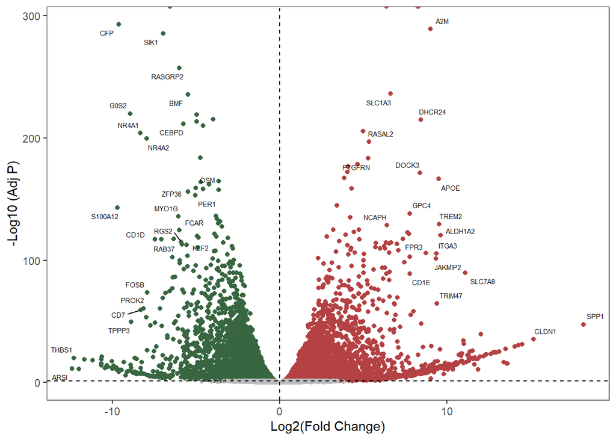

```r
library(ggplot2)
library(ggrepel)

res$logadjp = - log10(res$padj)

ggplot(res, aes(x = log2FoldChange, y = logadjp))+
  geom_point(data = subset(res, padj < 0.05 & log2FoldChange > 0),
             color = "#B44143")+
  geom_point(data = subset(res, padj < 0.05 & log2FoldChange < 0),
             color = "#386641")+
  geom_point(data = subset(res, padj > 0.05),
             color = "grey")+
  geom_point(data = subset(res,abs(log2FoldChange) < 0),
             color = "grey")+
  geom_hline(yintercept = -log10(0.05), linetype = "dashed") +
  geom_vline(xintercept = c(0), linetype = "dashed") +
  theme_bw() +
  theme(panel.grid = element_blank()) +
  xlab("Log2(Fold Change)") +
  ylab("-Log10 (Adj P)") +
  geom_text_repel(data = subset(res, abs(`log2FoldChange`) > 5 & padj < 0.05), aes(label=Gene), size = 2)
```

#### Heatmap

```r
library(gplots)

#with ntd
ntd <- assay(normTransform(dds))
ntd <- as.data.frame(ntd)
head(ntd)
```

```
##                     A1        A2        A3       B1       B2        B3
## WASH7P       11.338459 11.454356 11.958763 9.746795 9.756318 10.170731
## LOC729737    12.593891 13.565693 14.184317 8.955723 9.654154  6.844960
## LOC100132287  8.466123  8.277417  8.477487 3.258986 4.031876  2.669643
## LOC100288069  7.660551  9.069239  8.414474 6.047790 7.105189  6.988956
## FAM87B        5.870913  6.838535  6.293400 4.181595 4.719173  4.797718
## LINC00115     7.074696  6.557479  6.293400 5.455014 4.760629  5.622476
```

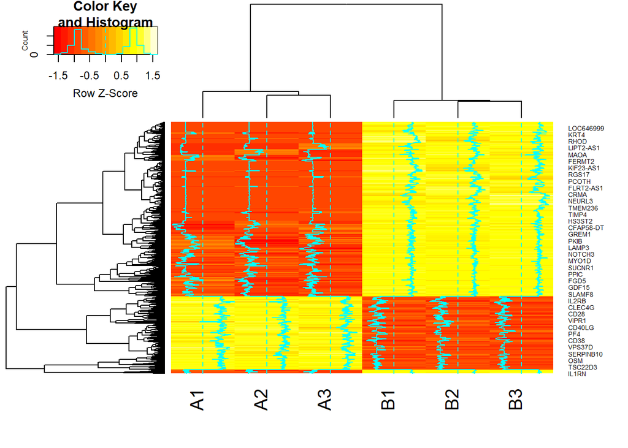

```r
fdr <- res[res$padj<0.05 & abs(res$log2FoldChange)>5,]
fdr <- na.omit(fdr)
mat <- ntd[rownames(fdr),]

heatmap_norm <- heatmap.2(as.matrix(mat), scale = "row")
```

```r
# extract z-scores of normalized counts
mat_norm = t(heatmap_norm$carpet)
```

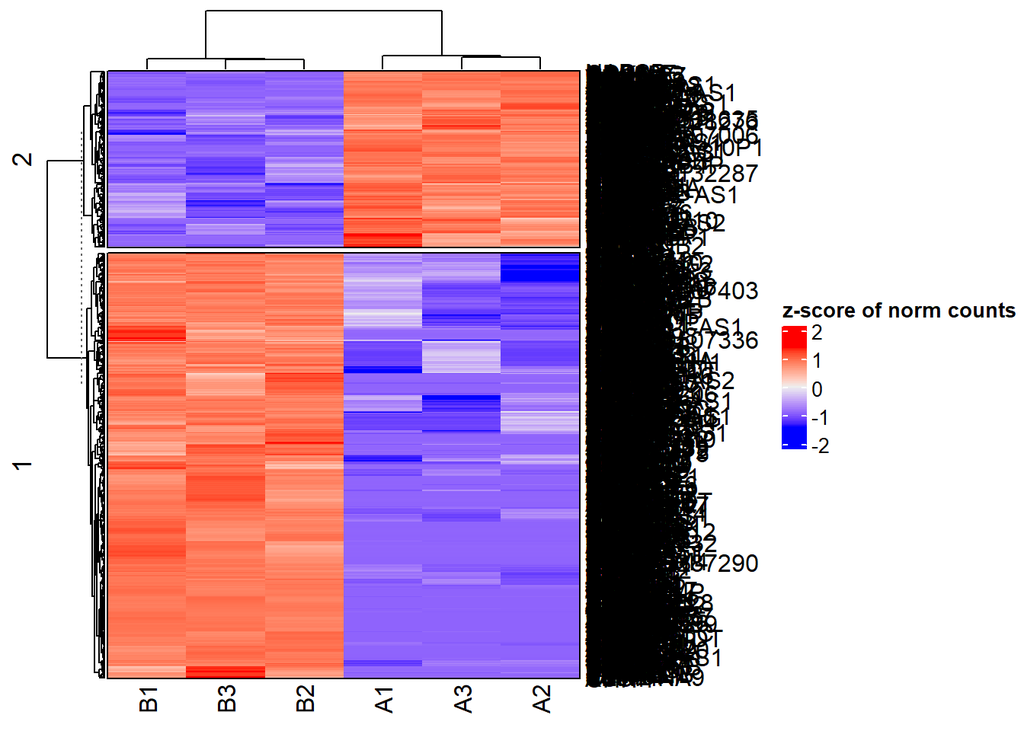

```r
library(ComplexHeatmap)

set.seed(123)
Heatmap(mat_norm, name = "z-score of norm counts",
                border = TRUE, k=2,
                row_gap = unit(1, "mm"), cluster_columns =T)
```

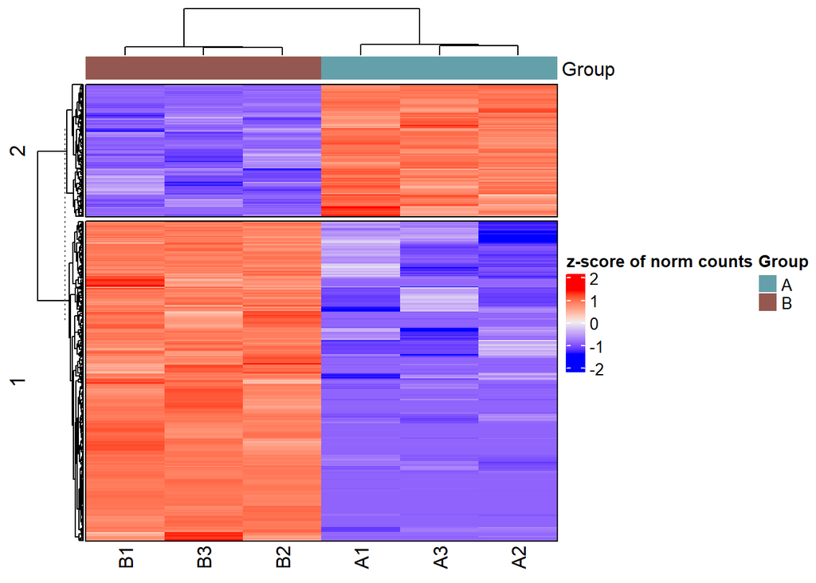

```r
column_ha = HeatmapAnnotation(Group = coldata$Group,
                                  col = list( Group = c(
                                    "A" = "#64a0aa",
                                    "B"="#955850ff")))
set.seed(123)
Heatmap(mat_norm, name = "z-score of norm counts",
                border = TRUE, k=2,
                row_gap = unit(1, "mm"), cluster_columns =T,
         top_annotation = column_ha,show_row_names = FALSE )
```

#### Plot the expression of individual genes

Select the most significant gene by padj (SCD).

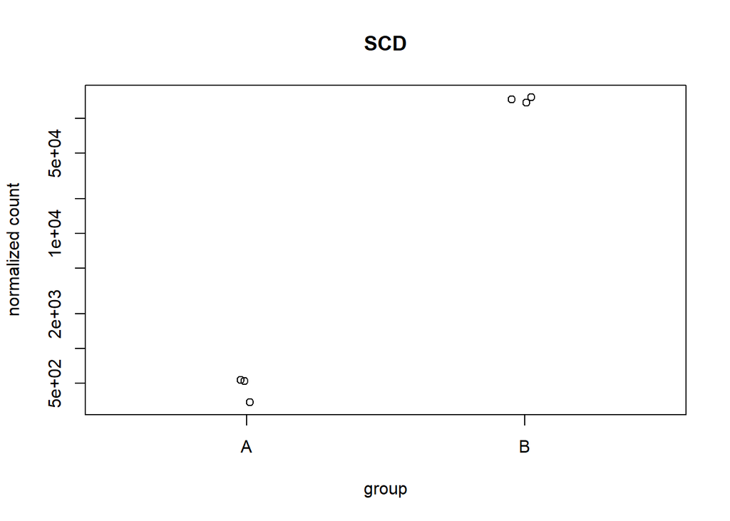

```r
plotCounts(dds=dds,gene = "SCD",intgroup = "Group")
```

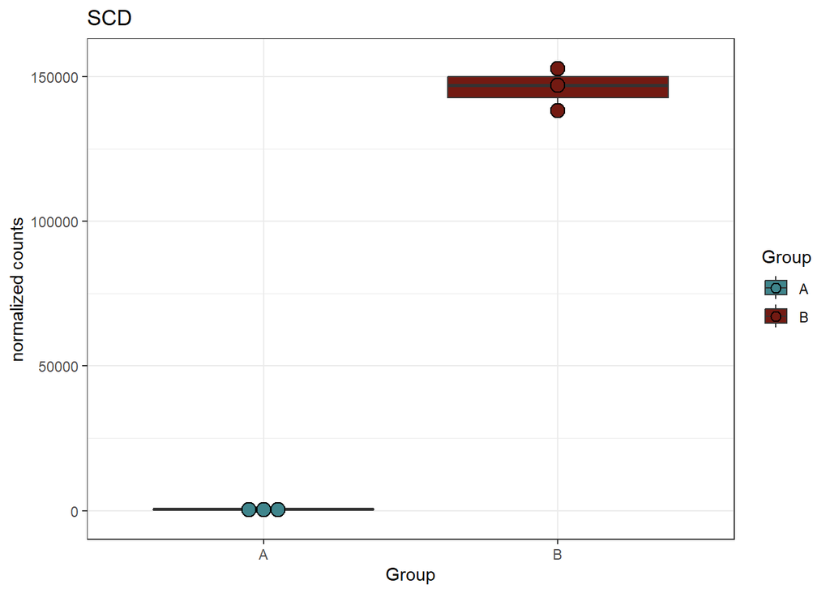

```r
norm_counts <- DESeq2::counts(dds, normalized=T)
norm_counts <- as.data.frame(norm_counts)

df<- as.matrix(norm_counts["SCD",])
df2 <- as.data.frame(t(df))
colnames(df2)<-"gene"
df3 <- cbind(df2,coldata)

ggplot(df3, aes(Group,gene, fill=Group)) +
  geom_boxplot()+
  geom_dotplot(binaxis = "y", stackdir = "center")+
  scale_fill_manual(values=c("#3f858c","#731a12"))+
        scale_x_discrete(limits=c("A","B"))+
        labs(title="SCD", y = "normalized counts")+
        theme_bw()
```

### Exercise 1

1.1. Using the same pipeline, perform a differential gene expression analysis by Sex. Plot the violin plot, the heatmap of the significant DEGs (padj < 0.05, absolute log2FoldChange > 2), and the most significant downregulated gene in “M”.